# 5 判别分析在R中的实现

Li Zongzhang

2022-09-25

本章介绍R中的判别分析工具。

```r
#安装和加载包
#install.packages("ggplot2")
#install.packages("tidyverse")
# install.packages("MASS")
# install.packages("klaR")
# install.packages("devtools")



library(ggplot2)
library(tidyverse)
```

# 1 考察观测变量的分布

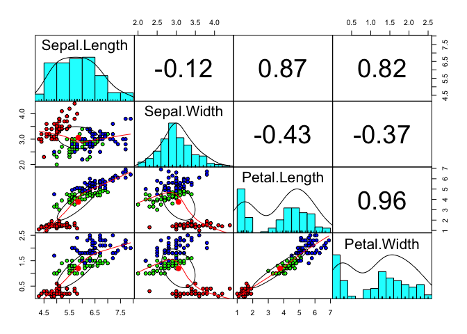

```r
library(psych)

#调用数据iris
data(iris)

#Correlation ellipses
#The narrower the ellipse
#the greater the correlation between the variables

pairs.panels(iris[1:4],
            gap = 0,
            bg = c("red", "green", "blue")[iris$Species],
            pch = 21)
```

# 2 判别函数的估计、预测和评估

## 2.1 估计

```r
#加载包MASS(Modern Applied Statistics with S)
#https://www.stats.ox.ac.uk/pub/MASS4/

library(MASS)

#估计linear discriminant model

# 写法一：
linear <- lda(Species ~ Sepal.Length + Sepal.Width + Petal.Length + Petal.Width, iris)
linear
```

```
Call:
lda(Species ~ Sepal.Length + Sepal.Width + Petal.Length + Petal.Width,
    data = iris)

Prior probabilities of groups:
    setosa versicolor  virginica
 0.3333333  0.3333333  0.3333333

Group means:
           Sepal.Length Sepal.Width Petal.Length Petal.Width
setosa            5.006       3.428        1.462       0.246
versicolor        5.936       2.770        4.260       1.326
virginica         6.588       2.974        5.552       2.026

Coefficients of linear discriminants:
                    LD1         LD2
Sepal.Length  0.8293776 -0.02410215
Sepal.Width   1.5344731 -2.16452123
Petal.Length -2.2012117  0.93192121
Petal.Width  -2.8104603 -2.83918785

Proportion of trace:
   LD1    LD2
0.9912 0.0088
```

```r
# 写法二：
linear <- lda(Species ~., iris)


#查看ld的属性
attributes(linear)
```

```
$names
 [1] "prior"   "counts"  "means"   "scaling" "lev"     "svd"     "N"
 [8] "call"    "terms"   "xlevels"

$class
[1] "lda"
```

```r
linear$prior
```

```
    setosa versicolor  virginica
 0.3333333  0.3333333  0.3333333
```

```r
linear$counts
```

```
    setosa versicolor  virginica
        50         50         50
```

```r
linear$means
```

```
           Sepal.Length Sepal.Width Petal.Length Petal.Width
setosa            5.006       3.428        1.462       0.246
versicolor        5.936       2.770        4.260       1.326
virginica         6.588       2.974        5.552       2.026
```

```r
linear$scaling
```

```
                    LD1         LD2
Sepal.Length  0.8293776 -0.02410215
Sepal.Width   1.5344731 -2.16452123
Petal.Length -2.2012117  0.93192121
Petal.Width  -2.8104603 -2.83918785
```

## 2.2 预测

```r
#保存判别函数的预测结果
p <- predict(linear, iris)

predict_class <- p$class
predict_class
```

```
  [1] setosa     setosa     setosa     setosa     setosa     setosa
  [7] setosa     setosa     setosa     setosa     setosa     setosa
 [13] setosa     setosa     setosa     setosa     setosa     setosa
 [19] setosa     setosa     setosa     setosa     setosa     setosa
 [25] setosa     setosa     setosa     setosa     setosa     setosa
 [31] setosa     setosa     setosa     setosa     setosa     setosa
 [37] setosa     setosa     setosa     setosa     setosa     setosa
 [43] setosa     setosa     setosa     setosa     setosa     setosa
 [49] setosa     setosa     versicolor versicolor versicolor versicolor
 [55] versicolor versicolor versicolor versicolor versicolor versicolor
 [61] versicolor versicolor versicolor versicolor versicolor versicolor
 [67] versicolor versicolor versicolor versicolor virginica  versicolor
 [73] versicolor versicolor versicolor versicolor versicolor versicolor
 [79] versicolor versicolor versicolor versicolor versicolor virginica
 [85] versicolor versicolor versicolor versicolor versicolor versicolor
 [91] versicolor versicolor versicolor versicolor versicolor versicolor
 [97] versicolor versicolor versicolor versicolor virginica  virginica
[103] virginica  virginica  virginica  virginica  virginica  virginica
[109] virginica  virginica  virginica  virginica  virginica  virginica
[115] virginica  virginica  virginica  virginica  virginica  virginica
[121] virginica  virginica  virginica  virginica  virginica  virginica
[127] virginica  virginica  virginica  virginica  virginica  virginica
[133] virginica  versicolor virginica  virginica  virginica  virginica
[139] virginica  virginica  virginica  virginica  virginica  virginica
[145] virginica  virginica  virginica  virginica  virginica  virginica
Levels: setosa versicolor virginica
```

```r
#预测新个案
new_case <- data.frame(Sepal.Length = c(5.1,5.9,6.6),
                       Sepal.Width = c(3.5,2.8,2.9),
                       Petal.Length = c(1.5,4.3,5.6),
                       Petal.Width = c(0.25,1.3,2.1))

new_class <- predict(linear, new_case)
new_class
```

```
$class
[1] setosa     versicolor virginica
Levels: setosa versicolor virginica

$posterior
        setosa   versicolor    virginica
1 1.000000e+00 1.117074e-20 3.314219e-40
2 2.963609e-20 9.998273e-01 1.727265e-04
3 4.169387e-42 3.505610e-05 9.999649e-01

$x
        LD1        LD2
1  7.701156 -0.3491879
2 -1.823849  0.7749274
3 -6.199781 -0.5182489
```

## 2.3 评估

```r
#绘制观测组别和预测组别的列联表
tab <- table(Actual = iris$Species, Predicted = predict_class)
tab
```

```
            Predicted
Actual       setosa versicolor virginica
  setosa         50          0         0
  versicolor      0         48         2
  virginica       0          1        49
```

```r
#计算预测正确率
sum(diag(tab))/sum(tab)
```

```
[1] 0.98
```

# 3 判别分析中的可视化工具

## 3.1 单个判别函数得分的直方图

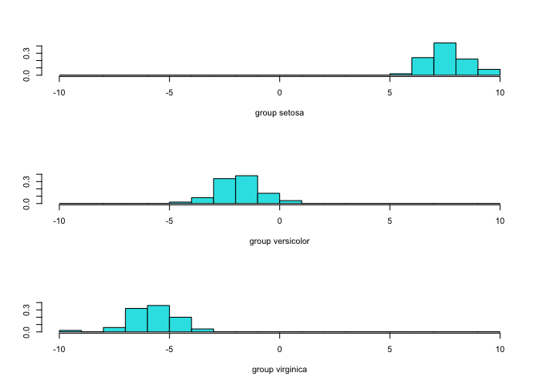

```r
#判别函数得分的histogram
library(MASS)

#保存预测结果
p <- predict(linear, iris)


#提取预测结果中存储的判别得分
ldahist(p$x[,1], iris$Species)
```

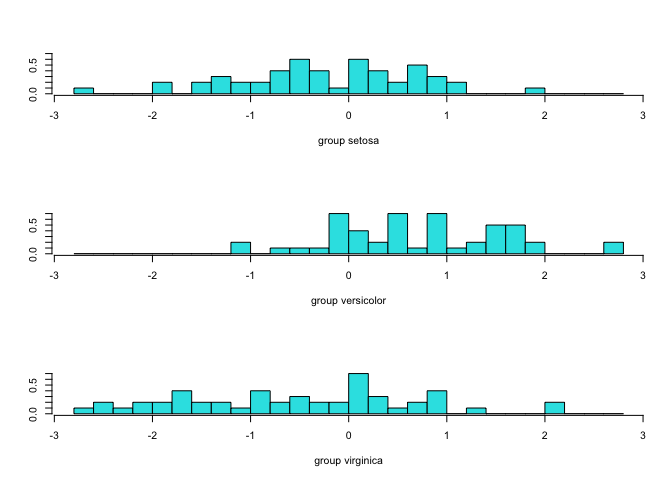

```r
ldahist(p$x[,2], iris$Species)
```

## 3.2 两个判别函数得分的二维图

```r
# Enable the r-universe repo
options(repos = c(
    fawda123 = 'https://fawda123.r-universe.dev',
    CRAN = 'https://cloud.r-project.org'))

# Install ggord
install.packages('ggord')
```

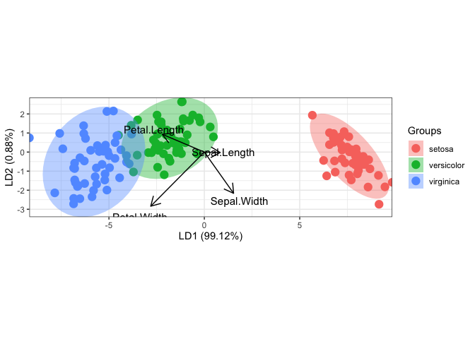

```r
#Bi-plot
library(devtools)
library(ggord)



ggord(linear, iris$Species)
```

```r
linear$scaling
```

```
                    LD1         LD2
Sepal.Length  0.8293776 -0.02410215
Sepal.Width   1.5344731 -2.16452123
Petal.Length -2.2012117  0.93192121
Petal.Width  -2.8104603 -2.83918785
```

## 3.3 评估观测变量的贡献 Partition plot

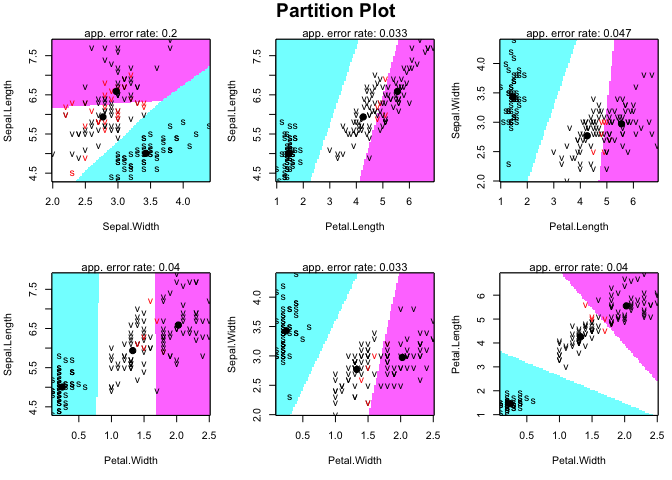

```r
# Partition plot
library(klaR)
#线性判别
partimat(Species ~., data = iris, method = "lda")
```

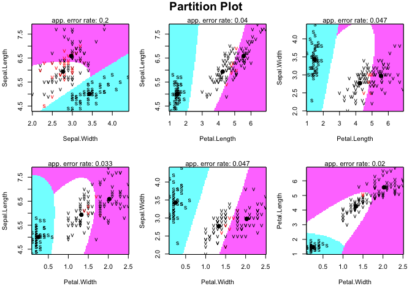

```r
#二次判别
partimat(Species ~., data = iris, method = "qda")
```

# 4 本章作业

**答题要求：将R的命令和输出结果转成图片，上传至91速课平台。**

**习题1: 教材P88,例题5.2**

要求： 1.1 报告教材P88-101的所有输出结果。

**习题2: 教材P98,例题5.5**

要求：只运用Fisher判别分析方法，不需要用距离判别和贝叶斯判别。报告教材P100-101的所有输出结果。

**习题3: 教材P104,习题5.3**

注意：本题只需要运用Fisher判别分析

要求：

3.1 报告判别分析模型的输出结果。

3.2 报告预测级别和实际级别的列联表。计算预测正确率。

3.3 绘制单个判别函数得分的直方图。

3.4 绘制判别函数得分两两之间的二维图形。

**习题4: 教材P105,习题5.5**

要求 4.1. 报告判别分析模型的输出结果，一共建立了几个判别函数，各个判别函数的贡献率是多大？

4.2 判别函数预测的正确率是多少？报告预测信用等级和实际信用等级的列联表。

4.3 绘制单个判别函数得分的直方图。

4.4 绘制判别函数得分两两之间的二维图形。